# Silas_Analysis

Max Kuttner

25 3 2020

## Hypothese 1

**[Erfolgt die Buchung von Flugtickets Dienstagabends, kann statistisch gesehen das preiswerteste Offert erzielt werden.]**

### Deskreptive Statistik:

```
##
##  DESCRIPTIVES
##
##  Descriptives
##  ----------------------------------------------------
##                          Preis    Wochentag    Zeit
##  ----------------------------------------------------
##    N                      7224         7224    7224
##    Missing                   0            0       0
##    Mean                   1.13
##    Median                 1.04
##    Standard deviation    0.346
##    Minimum               0.495
##    Maximum                6.00
##  ----------------------------------------------------
##
##
##  FREQUENCIES
##
##  Frequencies of Wochentag
##  ------------------------------------------------------
##    Levels        Counts    % of Total    Cumulative %
##  ------------------------------------------------------
##    Montag          1008          14.0            14.0
##    Dienstag        1008          14.0            27.9
##    Mittwoch        1008          14.0            41.9
##    Donnerstag      1050          14.5            56.4
##    Freitag         1050          14.5            70.9
##    Samstag         1050          14.5            85.5
##    Sonntag         1050          14.5           100.0
##  ------------------------------------------------------
##
##
##  Frequencies of Zeit
##  --------------------------------------------------
##    Levels    Counts    % of Total    Cumulative %
##  --------------------------------------------------
##    Morgen      2408          33.3            33.3
##    Mittag      2408          33.3            66.7
##    Abend       2408          33.3           100.0
##  --------------------------------------------------
```

### Verteilung - BoxPlot

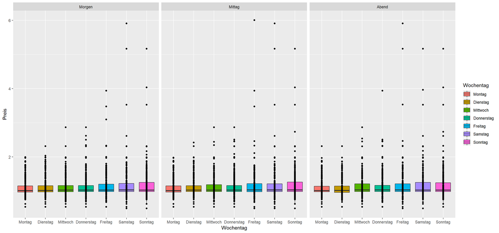

### Mehrfakorielle ANOVA:

```
##
##  ANOVA
##
##  ANOVA
##  ----------------------------------------------------------------------------------
##                 Sum of Squares    df      Mean Square    F         p        η²p
##  ----------------------------------------------------------------------------------
##    Wochentag            2.5126       6         0.4188    3.5122    0.002    0.003
##    Zeit                 0.0224       2         0.0112    0.0941    0.910    0.000
##    Residuals          860.2688    7215         0.1192
##  ----------------------------------------------------------------------------------
##
##
##  ESTIMATED MARGINAL MEANS
##
##  WOCHENTAG:ZEIT
##
##  Estimated Marginal Means - Wochentag:Zeit
##  ------------------------------------------------------------
##    Zeit      Wochentag     Mean    SE        Lower    Upper
##  ------------------------------------------------------------
##    Morgen    Montag        1.10    0.0123     1.08     1.13
##              Dienstag      1.11    0.0123     1.08     1.13
##              Mittwoch      1.12    0.0123     1.09     1.14
##              Donnerstag    1.13    0.0121     1.10     1.15
##              Freitag       1.14    0.0121     1.12     1.17
##              Samstag       1.15    0.0121     1.12     1.17
##              Sonntag       1.15    0.0121     1.13     1.18
##    Mittag    Montag        1.11    0.0123     1.08     1.13
##              Dienstag      1.11    0.0123     1.09     1.14
##              Mittwoch      1.12    0.0123     1.10     1.14
##              Donnerstag    1.13    0.0121     1.11     1.15
##              Freitag       1.15    0.0121     1.12     1.17
##              Samstag       1.15    0.0121     1.13     1.18
##              Sonntag       1.16    0.0121     1.13     1.18
##    Abend     Montag        1.11    0.0123     1.08     1.13
##              Dienstag      1.11    0.0123     1.09     1.13
##              Mittwoch      1.12    0.0123     1.10     1.14
##              Donnerstag    1.13    0.0121     1.11     1.15
##              Freitag       1.15    0.0121     1.12     1.17
##              Samstag       1.15    0.0121     1.13     1.17
##              Sonntag       1.16    0.0121     1.13     1.18
##  ------------------------------------------------------------
```

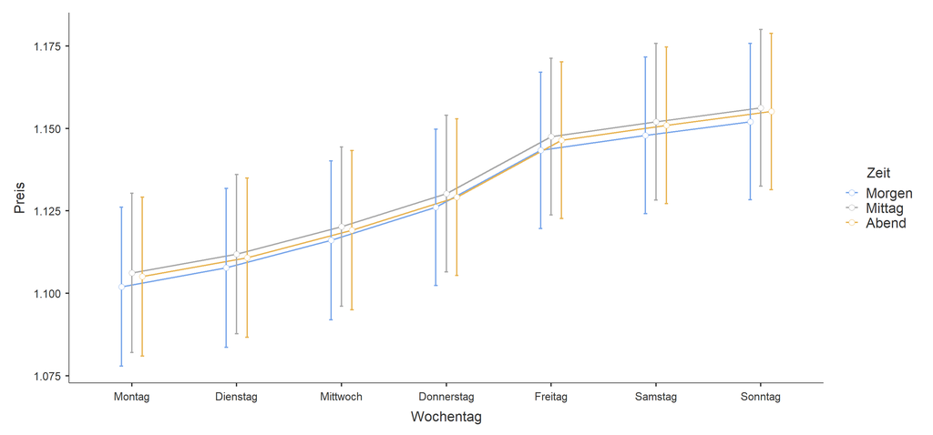

Estimated marginal means korrigiert Missverhältnisse aus unterschiedlich großen Sample-Größen für einzelne Tage. Somit wird jeder/jede Tag/Uhrzeit gleich gewertet. Wie oft jeder einzelne Tag gemessen wurde bzw. im Datensatz vorkommt, ist in der deskriptiven Statistik unter **FREQUENCIES** zu sehen. Für mehr Infos zum EMM: https://cran.r-project.org/web/packages/emmeans/vignettes/basics.html

Im folgenden werden Tage und Uhrzeiten nach ihrem mean (also **Preis**) angeordnet.

```
## # A tibble: 21 x 6
##    Zeit   Wochentag   mean     se lower upper
##    <fct>  <fct>      <dbl>  <dbl> <dbl> <dbl>
##  1 Morgen Montag      1.10 0.0123  1.08  1.13
##  2 Abend  Montag      1.11 0.0123  1.08  1.13
##  3 Mittag Montag      1.11 0.0123  1.08  1.13
##  4 Morgen Dienstag    1.11 0.0123  1.08  1.13
##  5 Abend  Dienstag    1.11 0.0123  1.09  1.13
##  6 Mittag Dienstag    1.11 0.0123  1.09  1.14
##  7 Morgen Mittwoch    1.12 0.0123  1.09  1.14
##  8 Abend  Mittwoch    1.12 0.0123  1.10  1.14
##  9 Mittag Mittwoch    1.12 0.0123  1.10  1.14
## 10 Morgen Donnerstag  1.13 0.0121  1.10  1.15
## # ... with 11 more rows
```

## Hypothese 2

**[Je spontaner und kurzfristiger die Kaufentscheidung getroffen wird, desto höher ist der offerierte Preis einer Airline.]**

```
## * `` -> ...1
## * `` -> ...5
```

**Diese Zeitreihe lässt sich mit folgendem Modell modellieren.**

```
## Series: myts
## ARIMA(1,2,1)
##
## Coefficients:
##          ar1      ma1
##       0.2165  -0.8956
## s.e.  0.1100   0.0580
##
## sigma^2 estimated as 0.001404:  log likelihood=317.47
## AIC=-628.94   AICc=-628.79   BIC=-619.53
##
## Training set error measures:
##                       ME       RMSE       MAE         MPE    MAPE MASE
## Training set 0.001348106 0.03703545 0.0216493 0.005775143 1.79834  NaN
##                   ACF1
## Training set 0.0445453
```

```
##
## z test of coefficients:
##
##      Estimate Std. Error z value Pr(>|z|)
## ar1  0.216510   0.109957   1.969  0.04895 *
## ma1 -0.895598   0.058046 -15.429  < 2e-16 ***
## ---
## Signif. codes:  0 '***' 0.001 '**' 0.01 '*' 0.05 '.' 0.1 ' ' 1
```

**Mit diesem Modell kann in weiterer Folge die Zeitrehe angenähert werden und bis zum 1.Februar 2020 vorhergesagt werden.**

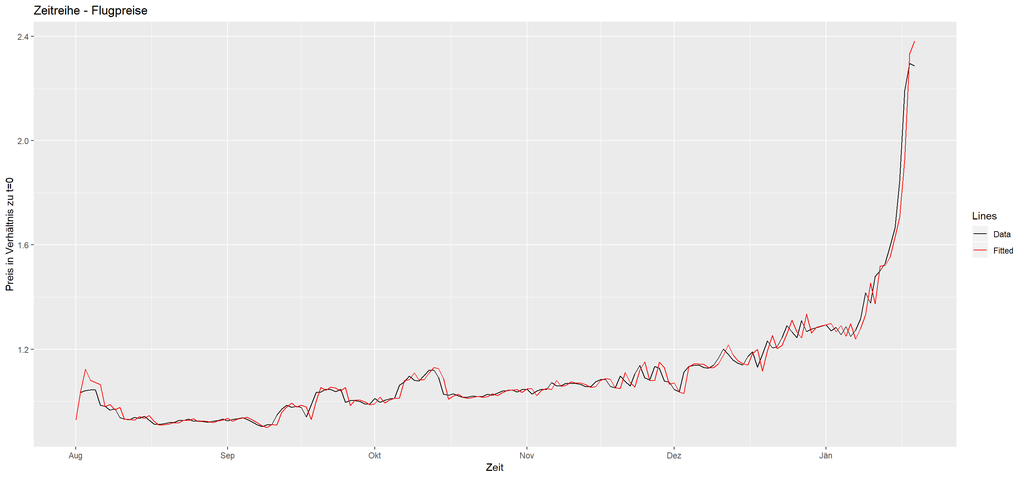

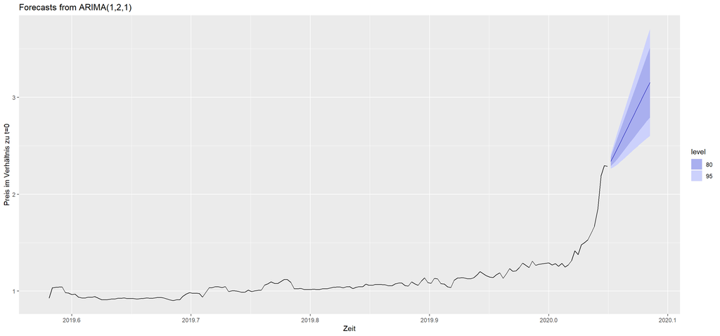

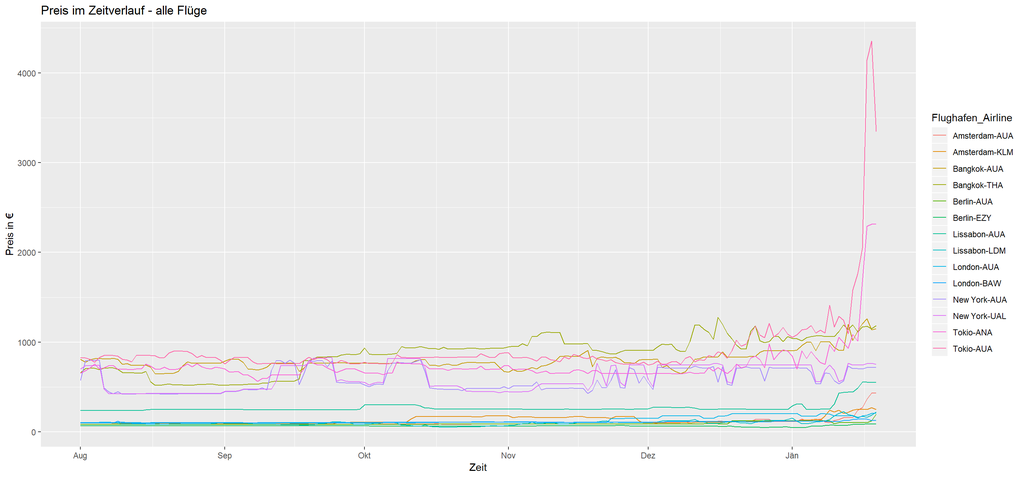

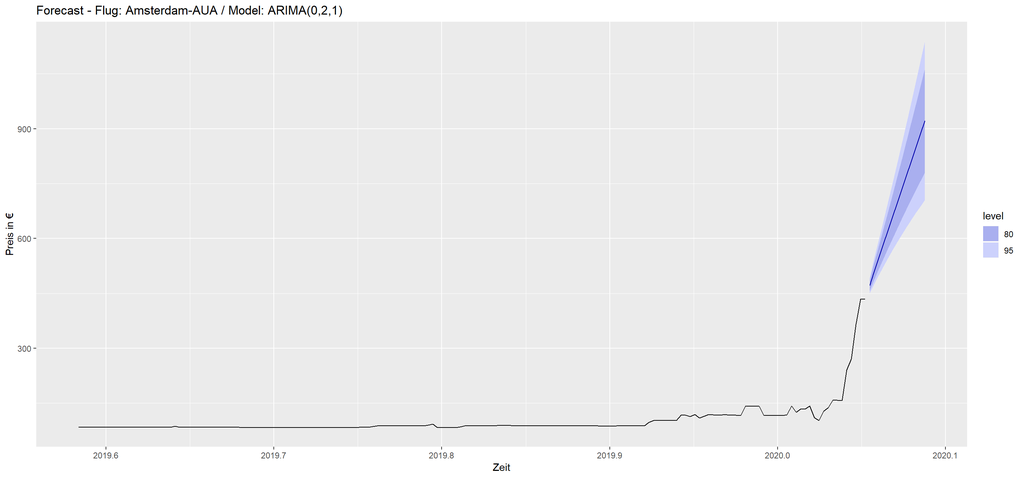

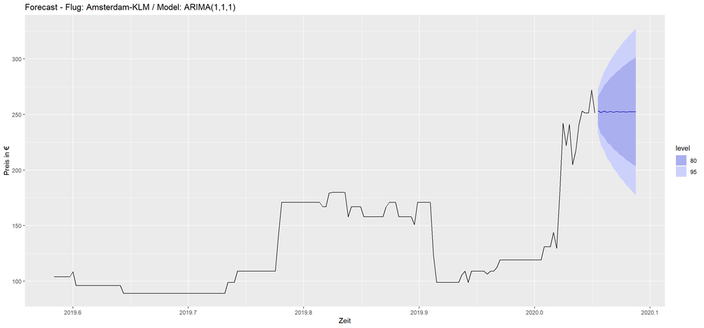

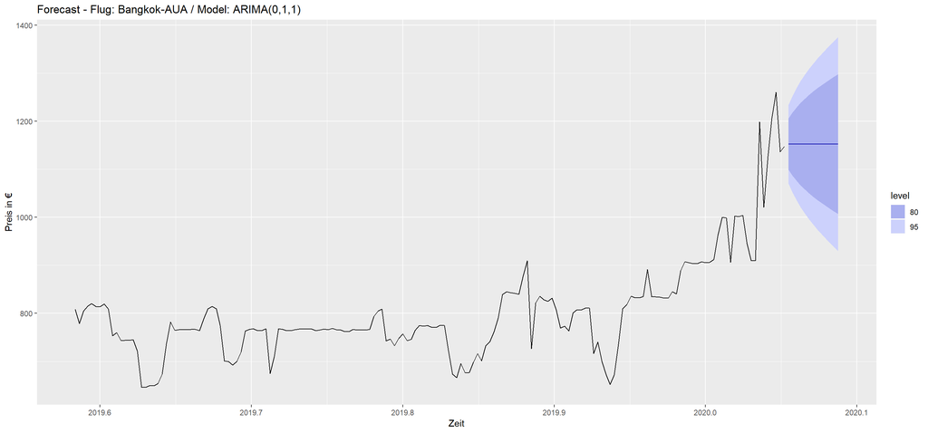

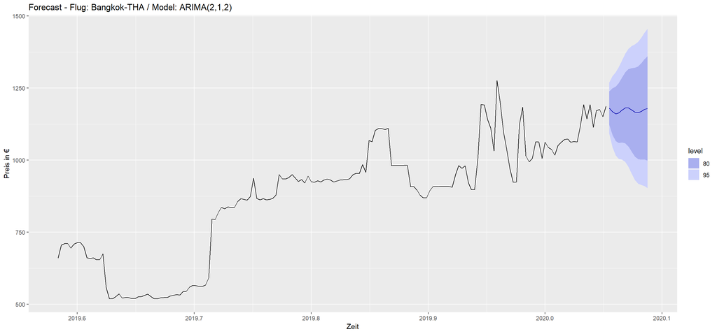

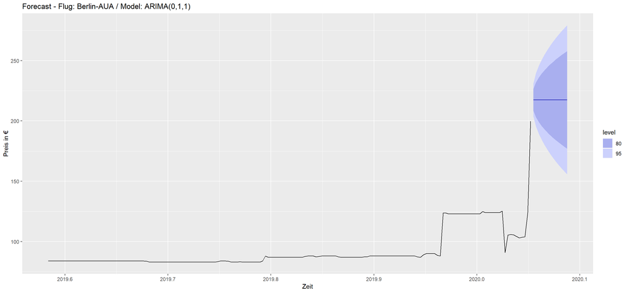

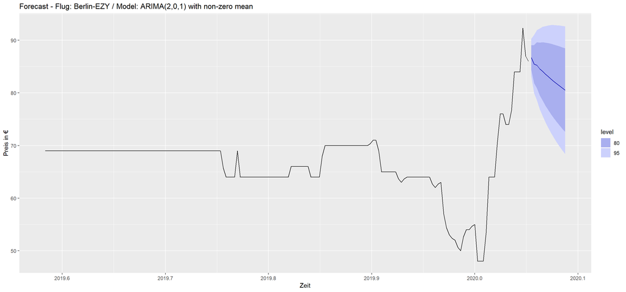

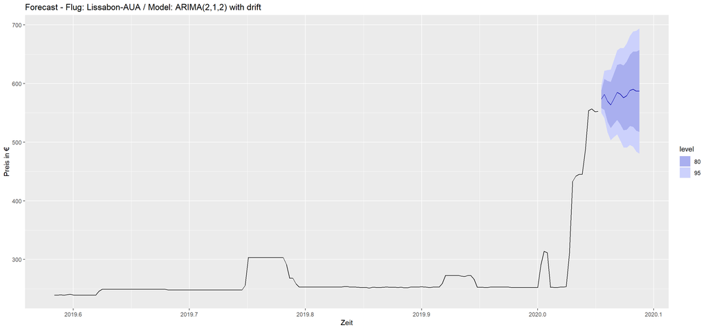

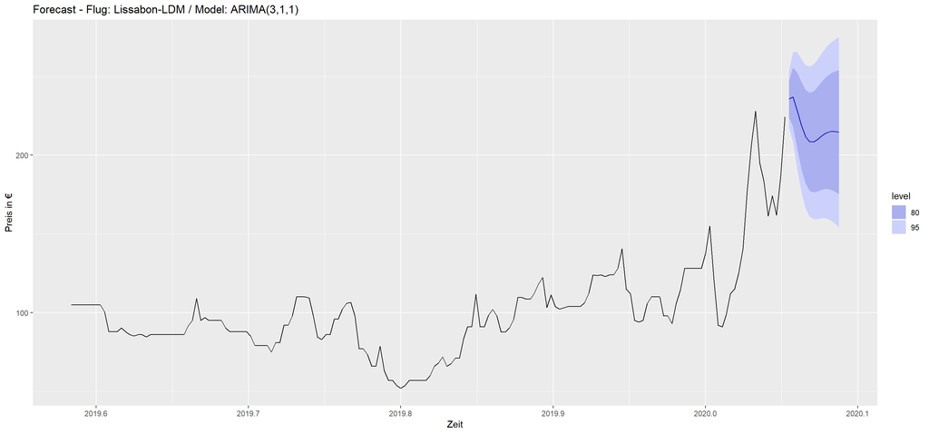

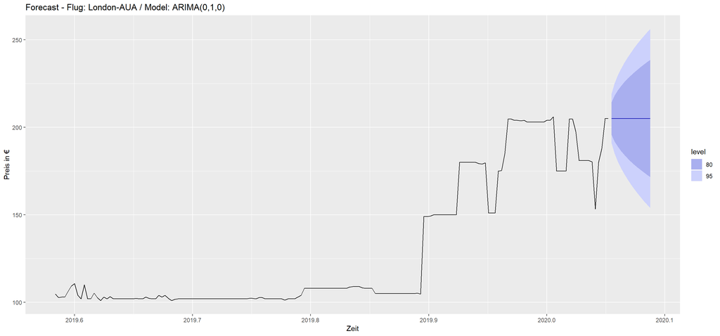

[19 more figures not shown]

### Preis im Verhältnis zu t=0

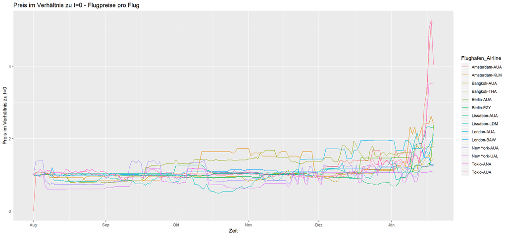

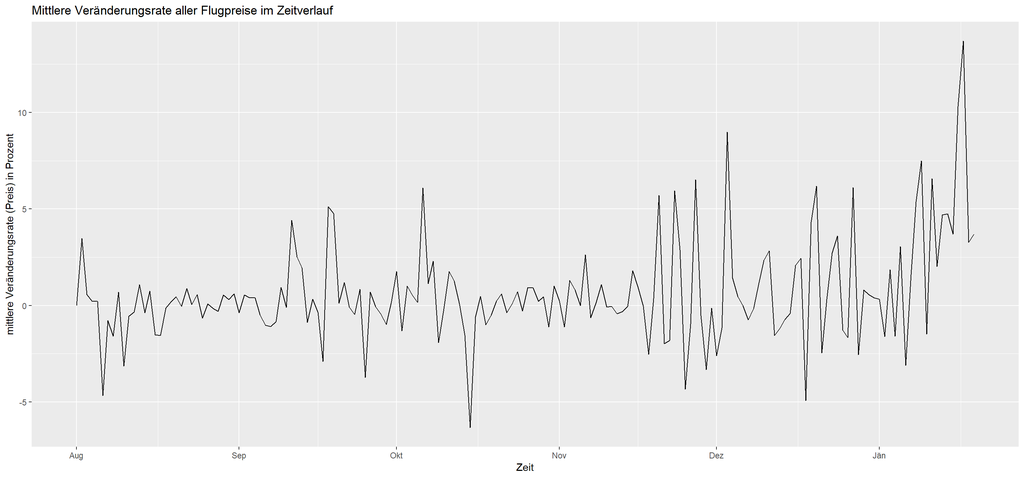

### BoxPlot Vergleich aller Flüge

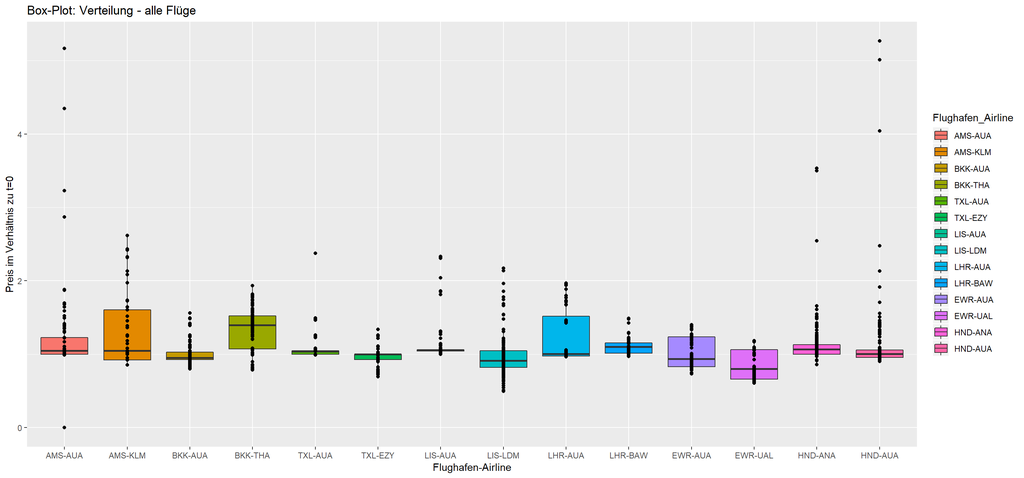

## Hypothese 3

**[Die Wahl des Betriebssystems respektive die Marke des Nutzerendgeräts mit dem die Reise-Website abgerufen wird, hat eine Auswirkung auf den offerierten Preis einer Airline.]**

### Deskreptive Statistik:

```
##
##  DESCRIPTIVES
##
##  Descriptives
##  -----------------------------------------
##                          Preis    Device
##  -----------------------------------------
##    N                       560       560
##    Missing                   0         0
##    Mean                   1.15
##    Median                 1.05
##    Standard deviation    0.243
##    Minimum               0.629
##    Maximum                1.98
##  -----------------------------------------
##
##
##  FREQUENCIES
##
##  Frequencies of Device
##  ----------------------------------------------------------
##    Levels            Counts    % of Total    Cumulative %
##  ----------------------------------------------------------
##    Apple Ipad           280          50.0            50.0
##    Samsung Galaxy       280          50.0           100.0
##  ----------------------------------------------------------
```

### Verteilung - BoxPlot

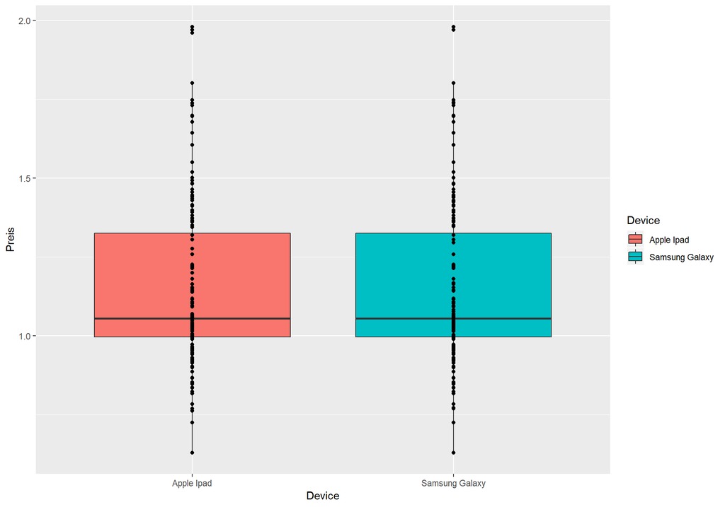

### Einfaktorielle ANOVA:

```
##
##  ANOVA
##
##  ANOVA
##  -------------------------------------------------------------------------
##                 Sum of Squares    df     Mean Square    F          p
##  -------------------------------------------------------------------------
##    Device              2.87e-5      1        2.87e-5    4.83e-4    0.982
##    Residuals              33.1    558         0.0593
##  -------------------------------------------------------------------------
##
##
##  ESTIMATED MARGINAL MEANS
##
##  DEVICE
##
##  Estimated Marginal Means - Device
##  ------------------------------------------------------
##    Device            Mean    SE        Lower    Upper
##  ------------------------------------------------------
##    Apple Ipad        1.15    0.0146     1.12     1.18
##    Samsung Galaxy    1.15    0.0146     1.12     1.18
##  ------------------------------------------------------
```

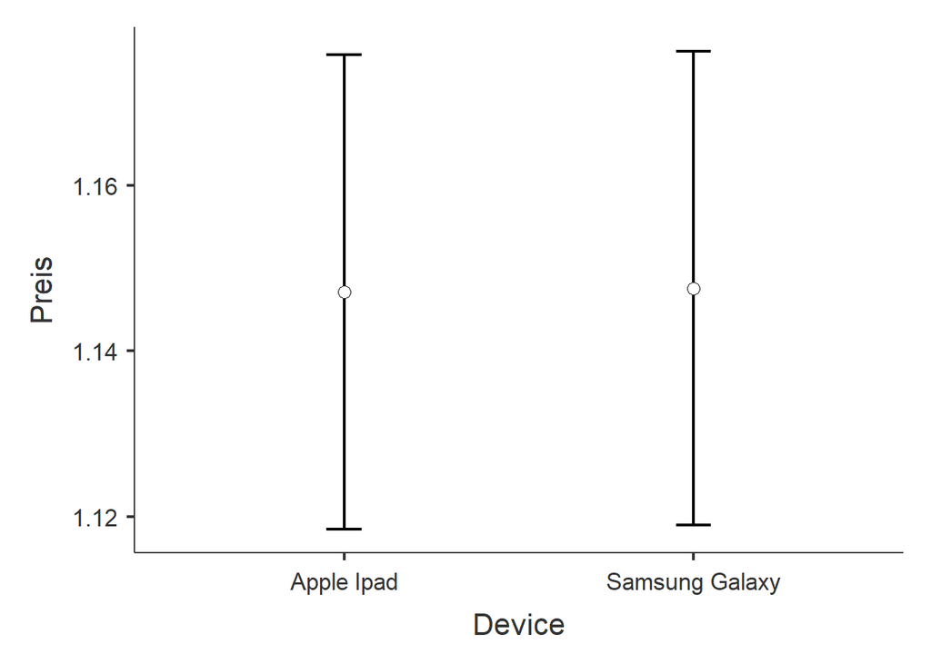

## Hypothese 4

**[Hypothese 4: Das Abrufen einer Reise-Website mittels Applikation und Website erwirkt einen Unterschied des offerierten Preises einer Airline.]**

### Deskreptive Statistik:

```
##
##  DESCRIPTIVES
##
##  Descriptives
##  -----------------------------------------------
##                          Preis    Datenzugriff
##  -----------------------------------------------
##    N                       560             560
##    Missing                   0               0
##    Mean                   1.15
##    Median                 1.05
##    Standard deviation    0.244
##    Minimum               0.629
##    Maximum                1.98
##  -----------------------------------------------
##
##
##  FREQUENCIES
##
##  Frequencies of Datenzugriff
##  ------------------------------------------------------------------
##    Levels                    Counts    % of Total    Cumulative %
##  ------------------------------------------------------------------
##    Checkfelix Application       280          50.0            50.0
##    Checkfelix Website           280          50.0           100.0
##  ------------------------------------------------------------------
```

### Verteilung - BoxPlot

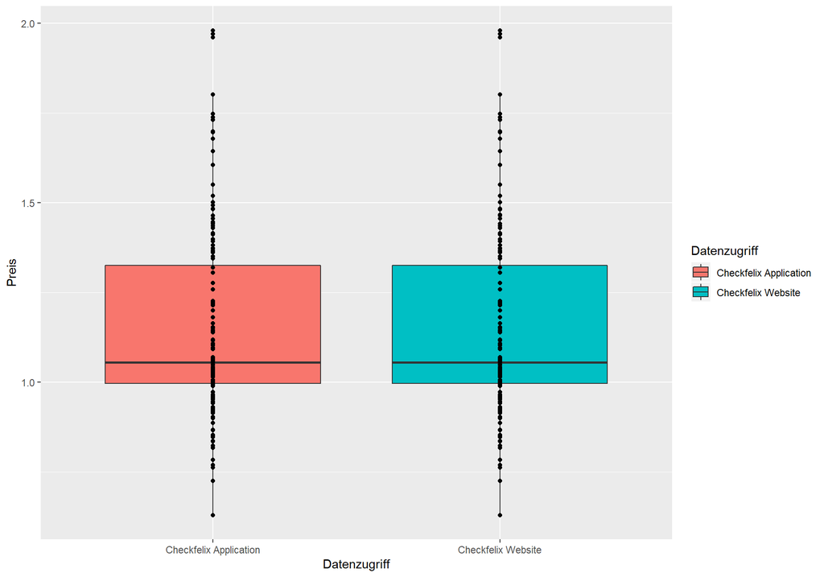

### Einfaktorielle ANOVA:

```
##
##  ANOVA
##
##  ANOVA
##  -------------------------------------------------------------------------------------
##                    Sum of Squares    df     Mean Square    F          p        η²p
##  -------------------------------------------------------------------------------------
##    Datenzugriff           4.85e-7      1        4.85e-7    8.14e-6    0.998    0.000
##    Residuals                 33.2    558         0.0595
##  -------------------------------------------------------------------------------------
##
##
##  ESTIMATED MARGINAL MEANS
##
##  DATENZUGRIFF
##
##  Estimated Marginal Means - Datenzugriff
##  --------------------------------------------------------------
##    Datenzugriff              Mean    SE        Lower    Upper
##  --------------------------------------------------------------
##    Checkfelix Application    1.15    0.0146     1.12     1.18
##    Checkfelix Website        1.15    0.0146     1.12     1.18
##  --------------------------------------------------------------
```

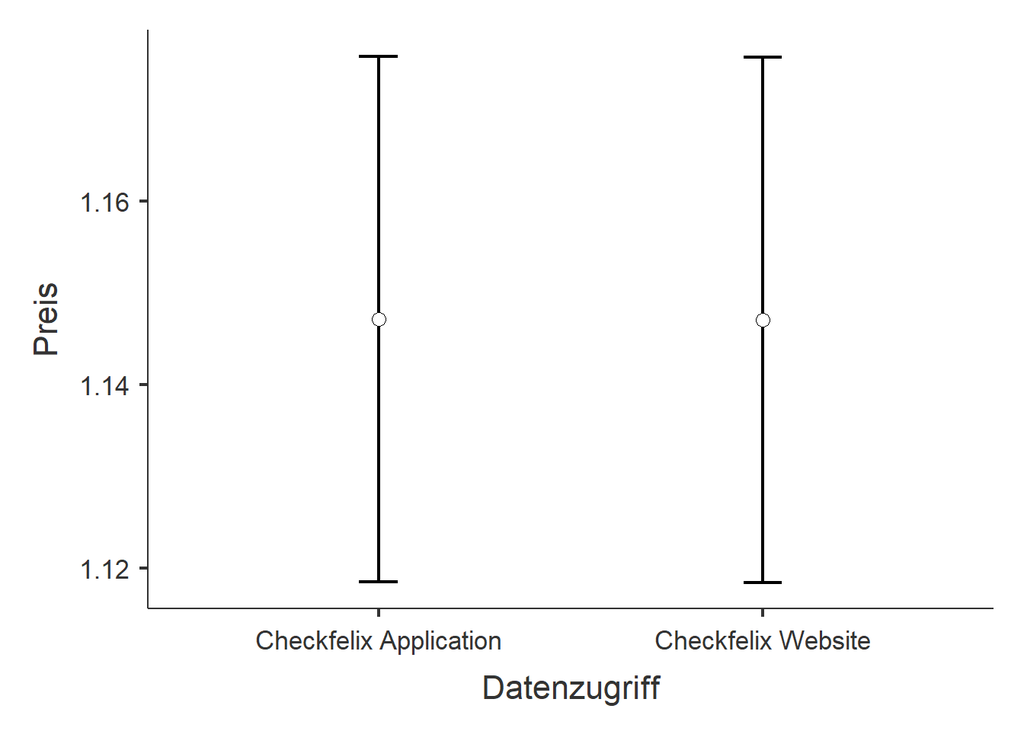

## Hypothese 6

**[Das Zurücksetzen von Cookies respektive dem Browserverlauf erwirkt ein Sinken des offerierten Preises einer Airline.]**

### Deskreptive Statistik:

```
##
##  DESCRIPTIVES
##
##  Descriptives
##  ------------------------------------------
##                          Preis    Cookies
##  ------------------------------------------
##    N                       560        560
##    Missing                   0          0
##    Mean                   1.15
##    Median                 1.05
##    Standard deviation    0.244
##    Minimum               0.629
##    Maximum                1.98
##  ------------------------------------------
##
##
##  FREQUENCIES
##
##  Frequencies of Cookies
##  ----------------------------------------------------------
##    Levels            Counts    % of Total    Cumulative %
##  ----------------------------------------------------------
##    Zugelassen           280          50.0            50.0
##    Zurueckgesetzt       280          50.0           100.0
##  ----------------------------------------------------------
```

### Verteilung - BoxPlot

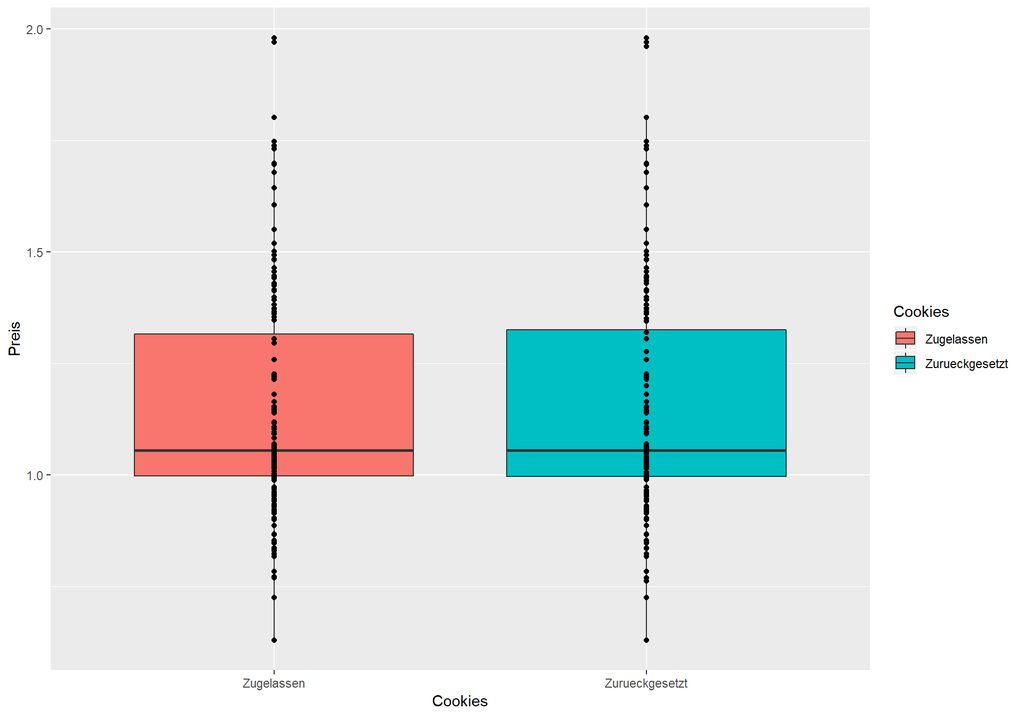

### Einfaktorielle ANOVA:

```
##
##  ANOVA
##
##  ANOVA
##  ----------------------------------------------------------------------------------
##                 Sum of Squares    df     Mean Square    F          p        η²p
##  ----------------------------------------------------------------------------------
##    Cookies             4.64e-5      1        4.64e-5    7.81e-4    0.978    0.000
##    Residuals              33.2    558         0.0595
##  ----------------------------------------------------------------------------------
##
##
##  ESTIMATED MARGINAL MEANS
##
##  COOKIES
##
##  Estimated Marginal Means - Cookies
##  ------------------------------------------------------
##    Cookies           Mean    SE        Lower    Upper
##  ------------------------------------------------------
##    Zugelassen        1.15    0.0146     1.12     1.18
##    Zurueckgesetzt    1.15    0.0146     1.12     1.18
##  ------------------------------------------------------
```

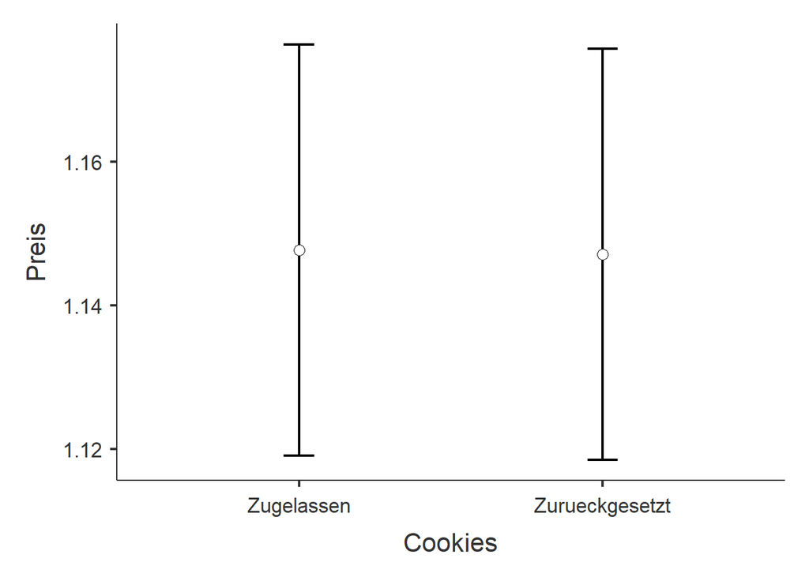

## Hypothese 7

**[Das Verbergen der Internetprotokoll-Adresse und folglich der ortsspezifischen Parameter mittels Virtual Private Network verursacht eine Differenz im offerierten Preis einer Airline.]**

### Deskreptive Statistik:

```
##
##  DESCRIPTIVES
##
##  Descriptives
##  ---------------------------------------------
##                          Preis    IP_Adresse
##  ---------------------------------------------
##    N                       560           560
##    Missing                   0             0
##    Mean                   1.50
##    Median                 1.36
##    Standard deviation    0.739
##    Minimum               0.696
##    Maximum                5.17
##  ---------------------------------------------
##
##
##  FREQUENCIES
##
##  Frequencies of IP_Adresse
##  -----------------------------------------------------
##    Levels       Counts    % of Total    Cumulative %
##  -----------------------------------------------------
##    Sichtbar        280          50.0            50.0
##    Verborgen       280          50.0           100.0
##  -----------------------------------------------------
```

### Verteilung - BoxPlot

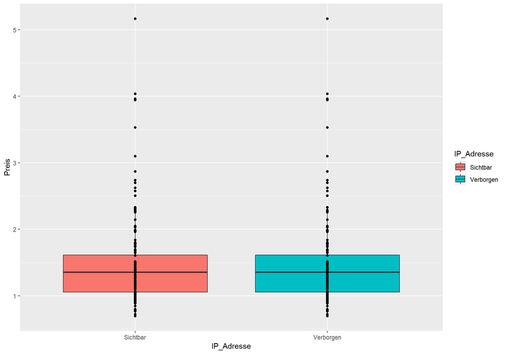

### Einfaktorielle ANOVA:

```
##
##  ANOVA
##
##  ANOVA
##  -----------------------------------------------------------------------------------
##                  Sum of Squares    df     Mean Square    F          p        η²p
##  -----------------------------------------------------------------------------------
##    IP_Adresse           9.15e-6      1        9.15e-6    1.67e-5    0.997    0.000
##    Residuals                305    558          0.547
##  -----------------------------------------------------------------------------------
##
##
##  ESTIMATED MARGINAL MEANS
##
##  IP_ADRESSE
##
##  Estimated Marginal Means - IP_Adresse
##  --------------------------------------------------
##    IP_Adresse    Mean    SE        Lower    Upper
##  --------------------------------------------------
##    Sichtbar      1.50    0.0442     1.42     1.59
##    Verborgen     1.50    0.0442     1.42     1.59
##  --------------------------------------------------
```

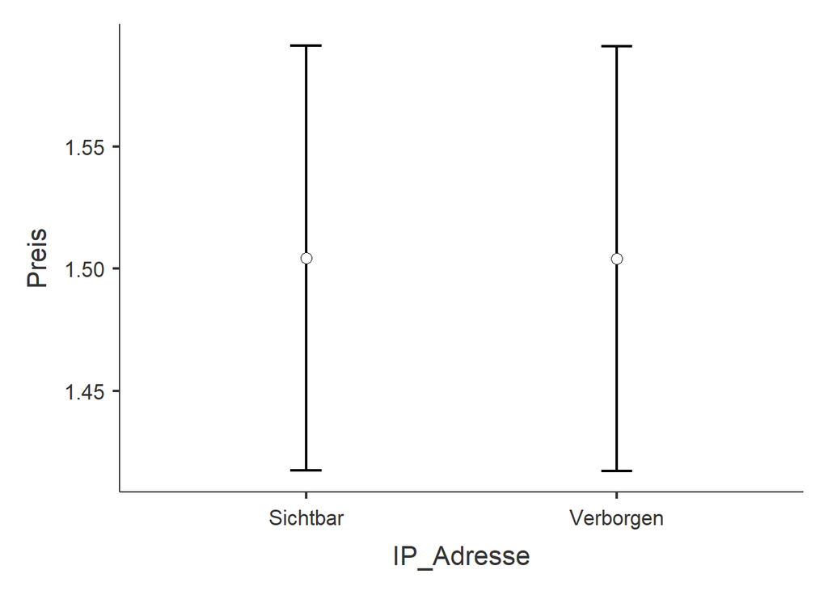

## Hypothese 8

**[Das Abrufen eines Flugpreises via Reise-Website führt, verglichen mit der Website der Airline selbst, zu einem höheren offerierten Preis.]**

### Deskreptive Statistik:

```
##
##  DESCRIPTIVES
##
##  Descriptives
##  -----------------------------------------------
##                          Preis    Datenzugriff
##  -----------------------------------------------
##    N                       280             280
##    Missing                   0               0
##    Mean                   1.21
##    Median                 1.06
##    Standard deviation    0.260
##    Minimum               0.835
##    Maximum                2.04
##  -----------------------------------------------
##
##
##  FREQUENCIES
##
##  Frequencies of Datenzugriff
##  --------------------------------------------------------------
##    Levels                Counts    % of Total    Cumulative %
##  --------------------------------------------------------------
##    Checkfelix Website       140          50.0            50.0
##    AUA Website              140          50.0           100.0
##  --------------------------------------------------------------
```

### Verteilung - BoxPlot

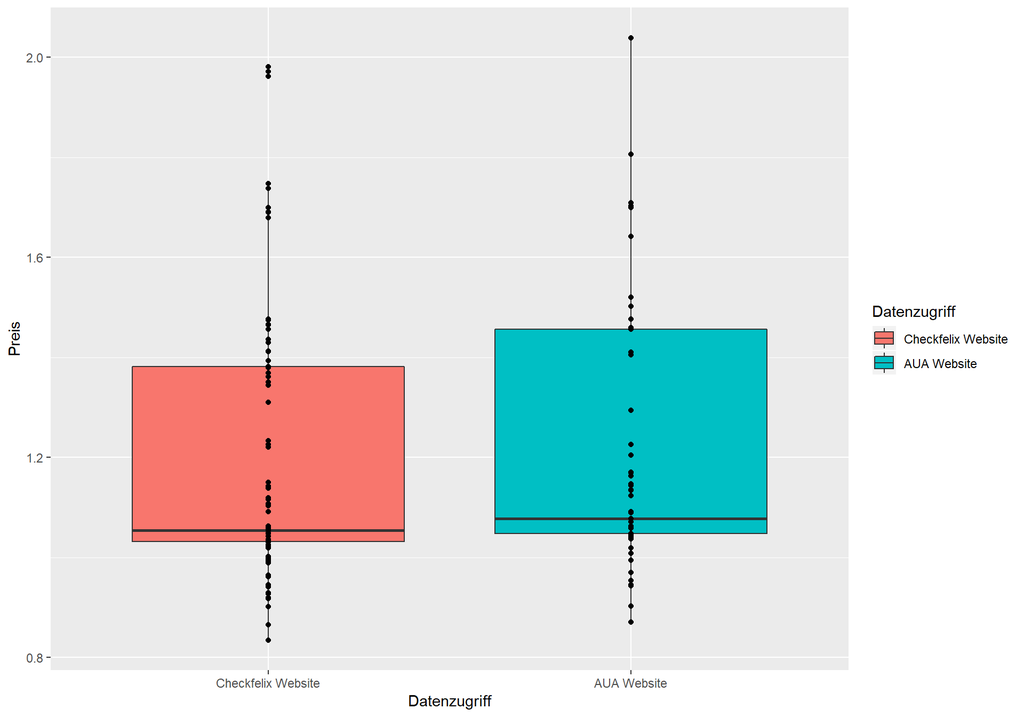

### Einfaktorielle ANOVA:

```
##
##  ANOVA
##
##  ANOVA
##  ----------------------------------------------------------------------------------
##                    Sum of Squares    df     Mean Square    F       p        η²p
##  ----------------------------------------------------------------------------------
##    Datenzugriff             0.112      1         0.1119    1.66    0.198    0.006
##    Residuals               18.704    278         0.0673
##  ----------------------------------------------------------------------------------
##
##
##  ESTIMATED MARGINAL MEANS
##
##  DATENZUGRIFF
##
##  Estimated Marginal Means - Datenzugriff
##  ----------------------------------------------------------
##    Datenzugriff          Mean    SE        Lower    Upper
##  ----------------------------------------------------------
##    Checkfelix Website    1.19    0.0219     1.14     1.23
##    AUA Website           1.23    0.0219     1.18     1.27
##  ----------------------------------------------------------
```

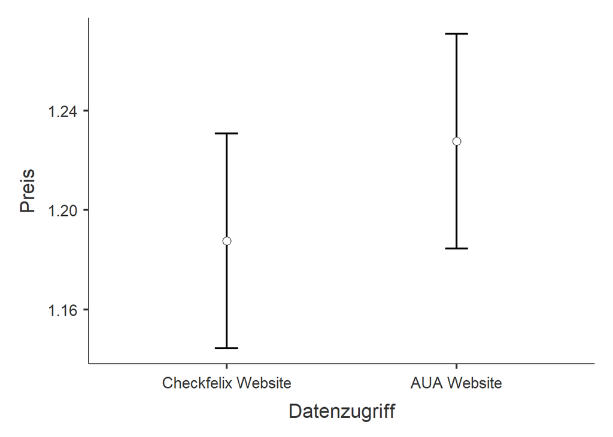